# Corona: modelling the outbreak

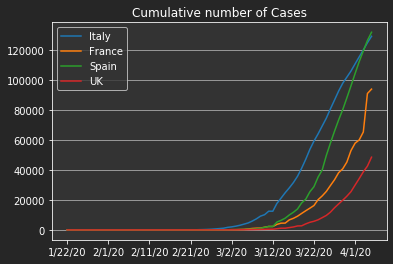

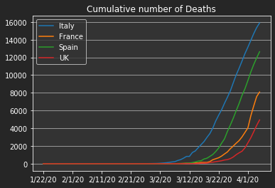

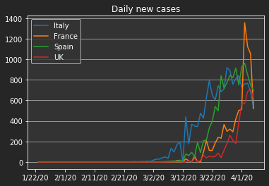

## Fit exponential

The growth of daily new cases can be fit by an exponential function which assume an underlying model of growth such that: $$ N_t = k N_{t-1} $$ With $N_t$ the number of new cases at day $t$.

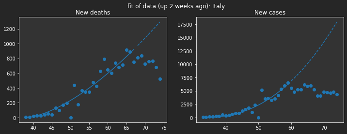

```
Day one: 43
Day one: 43
Day one: 34
```

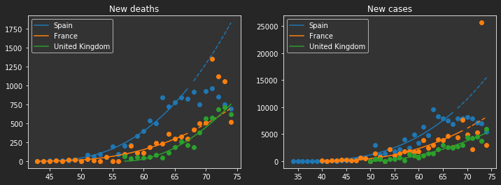

We see that the number of new cases and new deaths in Italy and Spain start to reach their peak and **do not** follow the exponential anymore. On the other hand, in the UK the slope is still rising.

## Cumulative growth on total number of cases and death

Now we can fit the sigmoidal curve to predict when it will plateau and at which value...

This assumes that the growth cannot continue infinitely and will eventually plateau when the number of cases reaches fulll capacity of the population (given current circumstances such as regulation on social distancing, confinment, testing, hospital capacity etc...).

The model becomes:

$$ N_t = kN_{t-1}(C-N_{t-1}) $$

Where $N_t$ now represents the **total** number of reported cases and $C$ the total capacity (hence cumulative number, which in theory does not give a heteroscedastic variable, such model is *not* a valid fit statistically).

```
Day one: 33
Day one: 30
```

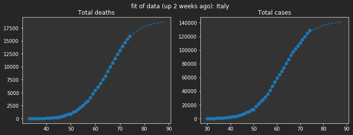

```
Day one: 44
Day one: 34
```

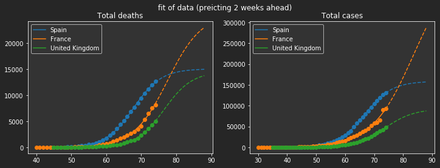

Again we see how Italy and Spain both passed the inflection point, and start to curb the curves. Howeve, for France and the UK we are quite below that point, so those predictions are likely innacurate.